# Data Representation

### Matching complicated patterns: regular expressions

- sometimes you want to match a pattern that is more complicated than a fixed string. For instance, how would you find all strings that have a vowel in them? Or match an email address?
- **regular expressions** (regexps) are a concise way of solving this problem, but they aren't pretty
- don't try and memorize all this, just get an idea of what's possible and then look at the cheat sheet later
- a regular expression is a string that is interpreted in a particular way as a query
- all of the `str_` functions we've talked about take regular expressions as queries.

```r
> x <- c("apple", "banana", "pear")
> str_subset(x, "an")
[1] "banana"
```

- The `.` matches any character

```r
> str_subset(x, ".a.")
[1] "banana" "pear"
```

### Repetition

```r
> babs = c("bb", "bab", "baab", "baaab")
```

- + after a character means match that character one or more times

```r
> str_subset(babs, "ba+b")
[1] "bab"   "baab"  "baaab"
```

- * after a character means match that character zero or more times

```r
> str_subset(babs, "ba*b")
[1] "bb"    "bab"   "baab"  "baaab"
```

- ? after a character means match that character zero or one time

```r
> str_subset(babs, "ba?b")
[1] "bb"  "bab"
```

- {n,m} after a character means match between n and m repetitions

```r
> str_subset(babs, "ba{2,3}b")
[1] "baab"  "baaab"
```

### Anchors

- anchors tell the regexp to look at particular places in the string
- `^` matches the beginning
- `$` matches the end

```r
> x <- c("apple", "banana", "pear")
> str_subset(x, "^a")
[1] "apple"
> str_subset(x, "a$")
[1] "banana"
```

### Character classes

- Besides `.`, here are some other special sequences that match categories of characters
- `\\d`: matches any digit.
- `\\s`: matches any whitespace (e.g. space, tab, newline).
- `[abc]`: matches a, b, or c.
- `[a-zA-Z]`: matches any letter
- `[^abc]`: matches anything except a, b, or c.

```r
> str_subset(c("abc", "xyz"), "[aeiou]")
[1] "abc"
```

### Exercise: what does this regex match?

`"^[a-zA-Z]+\\d+[a-zA-Z]+$"`

### Answer: what does this regex match?

`"^[a-zA-Z]+\\d+[a-zA-Z]+$"` matches any string starting with a letter and ending a letter, but containing at least one number

```r
> test_strs = c("c12341aaa", "123aa", "ba123", "asf  asdf", "G5s")
> str_subset(test_strs, "^[a-zA-Z]+\\d+[a-zA-Z]+$")
[1] "c12341aaa" "G5s"
```

### Escaping special characters

- `\\` is used to escape special characters in regexps so that they can be interpreted literally

```r
> str_extract(c("abc", "a.c", "bef"), "a\\.c")
[1] NA    "a.c" NA
```

- It takes two `\\` because a regex is a string. Thus the first `\` puts a literal `\` in the string, which is then interpreted as an escape character by the regex engine.

### Extracting matches

- `str_extract()` will get the portion of the string that matches your regex

```r
> emails = c("karina@stanford.edu", "nathalie@gmail.com", "carlos@kp.org")
> str_extract(emails, "@.*")
[1] "@stanford.edu" "@gmail.com"    "@kp.org"
```

### Exercise: domain names

```r
> emails = c("karina@stanford.edu", "nathalie@gmail.com", "carlos@kp.org")
```

Get the first part of the domain name out of these email addresses (for instance `kp` from `carlos@kp.org`)

### Exercise: domain names

```r
> emails = c("karina@stanford.edu", "nathalie@gmail.com", "carlos@kp.org")
```

Get the first domain names out of these email addresses (for instance `kp` from `carlos@kp.org`)

```r
> emails %>%
+   str_extract("@.*\\.") %>%
+   str_sub(2,-2)
[1] "stanford" "gmail"    "kp"
```

### Look-arounds

- Sometimes you want to check if a string matches a pattern and then only return part of that pattern.
- For example, if you're looking for history of disease, you may want the disease, but not the term “history of”

```r
> notes = c("... patient has history of MI ...",
+           "... family history of diabetes ...",
+           "... patient has nausea ... ")
> str_extract(notes, "(?<=history of )[a-zA-Z]+(?= )")
[1] "MI"       "diabetes" NA
```

- `(?=...)`: positive look-ahead assertion. Matches if … matches at the current input.
- `(?!...)`: negative look-ahead assertion. Matches if … does not match at the current input.
- `(?<=...)`: positive look-behind assertion. Matches if … matches text preceding the current position, with the last character of the match being the character just before the current position.
- `(?<!...)`: negative look-behind assertion. Matches if … does not match text preceding the current position.

### Regex is a broad topic

- There is a lot more to learn. This is a regex that matches valid email addresses:

[output not shown]

- But you can go very far with very little!
- Regex is not just in R, it is used across almost every programming language

### stringr cheat sheet

[figure not shown]

## Factors

### Factor basics

- factors are R's representation of variables that can take values in a limited number of categoires
- the `tidyverse`-adjacent `forcats` (forcats = for-categoricals, also an anagram of factor!) package has useful functions for working with them

```r
> library(forcats)
```

- consider a variable that stores a month of the year:

```r
> months_vec <- c("Dec", "Apr", "Jan", "Mar")
```

- if you sort this vector, it sorts alphabetically, not by the order of the months
- you can accidentally add months that aren't legitimate: `c(months_vec, "Jam")`
- you can make a factor by hand with `factor()`

```r
> month_levels <- c(
+   "Jan", "Feb", "Mar", "Apr", "May", "Jun",
+   "Jul", "Aug", "Sep", "Oct", "Nov", "Dec"
+ )
> factor(months_vec, levels = month_levels)
[1] Dec Apr Jan Mar
Levels: Jan Feb Mar Apr May Jun Jul Aug Sep Oct Nov Dec
```

### Factor levels

```r
> month_levels <- c(
+   "Jan", "Feb", "Mar", "Apr", "May", "Jun",
+   "Jul", "Aug", "Sep", "Oct", "Nov", "Dec"
+ )
> factor(months_vec, levels = month_levels)
[1] Dec Apr Jan Mar
Levels: Jan Feb Mar Apr May Jun Jul Aug Sep Oct Nov Dec
```

- the “levels” of the factor are the values that it is allowed to take as well as the order that it should be sorted in if desired
- `levels()` returns a character vector of the factor levels
- if the levels are not supplied, it takes the values in the vector as the levels in alphabetical order

```r
> factor(months_vec)
[1] Dec Apr Jan Mar
Levels: Apr Dec Jan Mar
```

- you can set the order of the levels to be by the order in which they appear in the vector using `fct_inorder()`

```r
> factor(months_vec) %>%
+   fct_inorder()
[1] Dec Apr Jan Mar
Levels: Dec Apr Jan Mar
```

### Example: gss_cat

- This is an example data frame loaded by `forcats` that has many factor columns, which are identifiable by the `<fct>` tag
- It’s a sample of data from the General Social Survey, which is a long-running US survey conducted by the independent research organization NORC at the University of Chicago.

```r
> gss_cat
# A tibble: 21,483 x 9
    year marital     age race  rincome   partyid    relig   denom   tvhours
   <int> <fct>     <int> <fct> <fct>     <fct>      <fct>   <fct>     <int>
 1  2000 Never ma…    26 White $8000 to… Ind,near … Protes… Southe…      12
 2  2000 Divorced     48 White $8000 to… Not str r… Protes… Baptis…      NA
 3  2000 Widowed      67 White Not appl… Independe… Protes… No den…       2
 4  2000 Never ma…    39 White Not appl… Ind,near … Orthod… Not ap…       4
 5  2000 Divorced     25 White Not appl… Not str d… None    Not ap…       1
 6  2000 Married      25 White $20000 -… Strong de… Protes… Southe…      NA
 7  2000 Never ma…    36 White $25000 o… Not str r… Christ… Not ap…       3
 8  2000 Divorced     44 White $7000 to… Ind,near … Protes… Luther…      NA
 9  2000 Married      44 White $25000 o… Not str d… Protes… Other         0
10  2000 Married      47 White $25000 o… Strong re… Protes… Southe…       3
# … with 21,473 more rows
```

```r
> gss_cat %>%
+   pull(marital) %>%
+   levels()
[1] "No answer"     "Never married" "Separated"     "Divorced"
[5] "Widowed"       "Married"
```

### Ordering factor levels

- It’s often useful to change the order of the factor levels in a visualisation
- For example, imagine you want to explore the average number of hours spent watching TV per day across religions

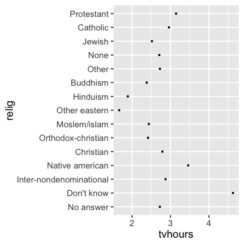

```r
> relig_tv = gss_cat %>%
+   group_by(relig) %>%
+   summarise(
+     age = mean(age, na.rm = TRUE),
+     tvhours = mean(tvhours, na.rm = TRUE),
+     n = n())
> ggplot(relig_tv, aes(tvhours, relig)) +
+   geom_point()
```

### Ordering factor levels

- It would be better if the religions in this plot were ordered according to the number of TV hours

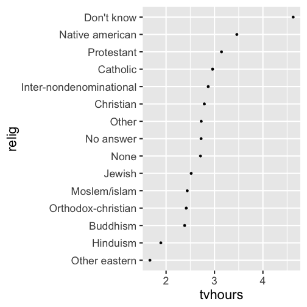

```r
> relig_tv %>%
+   mutate(relig = fct_reorder(relig, tvhours)) %>%
+ ggplot(aes(tvhours, relig)) +
+   geom_point()
```

- `fct_reorder()` takes in a factor vector and a numeric vector that is used to sort the levels

### Ordering factor levels

- `fct_infreq()` orders by how often the levels appear in the factor vector
- `fct_rev()` reverses the order

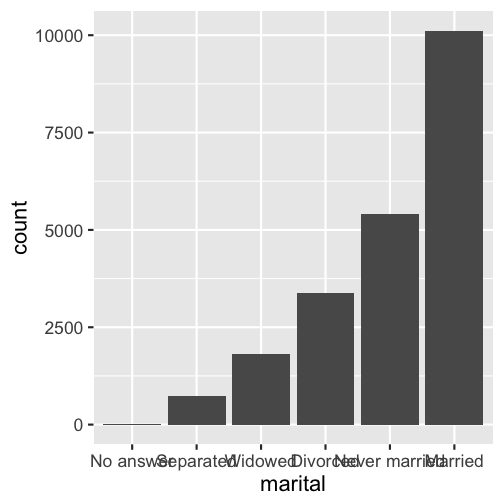

```r
> gss_cat %>%
+   mutate(marital = marital %>%
+         fct_infreq() %>%
+         fct_rev()) %>%
+ ggplot(aes(marital)) +
+   geom_bar()
```

### Recoding factor levels

```r
> gss_cat %>%
+   group_by(partyid) %>%
+   summarize(count=n()) %>%
+   arrange(desc(count))
# A tibble: 10 x 2
   partyid            count
   <fct>              <int>
 1 Independent         4119
 2 Not str democrat    3690
 3 Strong democrat     3490
 4 Not str republican  3032
 5 Ind,near dem        2499
 6 Strong republican   2314
 7 Ind,near rep        1791
 8 Other party          393
 9 No answer            154
10 Don't know             1
```

- These factor levels are terrible
- we can change them with `fct_recode()`

### Recoding factor levels

```r
> gss_cat %>%
+   mutate(partyid = fct_recode(partyid,
+     "Republican, strong"    = "Strong republican",
+     "Republican, weak"      = "Not str republican",
+     "Independent, near rep" = "Ind,near rep",
+     "Independent, near dem" = "Ind,near dem",
+     "Democrat, weak"        = "Not str democrat",
+     "Democrat, strong"      = "Strong democrat"
+   )) %>%
+   pull(partyid) %>%
+   levels()
 [1] "No answer"             "Don't know"
 [3] "Other party"           "Republican, strong"
 [5] "Republican, weak"      "Independent, near rep"
 [7] "Independent"           "Independent, near dem"
 [9] "Democrat, weak"        "Democrat, strong"
```

- Levels that you don't mention are left alone
- You can code multiple old levels to one new level (also see `?fct_collapse`)

### Exercise: plotting factors over time

How have the proportions of people identifying as Democrat, Republican, and Independent changed over time? Make a plot to explore. `geom_bar()` may be useful. `scale_fill_manual()` may also be useful to associate parties with their familiar colors.

### Answer: plotting factors over time

How have the proportions of people identifying as Democrat, Republican, and Independent changed over time? Make a plot to explore. `fct_collapse()` and `geom_bar()` may be useful. `scale_fill_manual()` may also be useful to associate parties with their familiar colors.

```r
> plot_data = gss_cat %>%
+   mutate(partyid = fct_collapse(partyid,
+     Democrat = c("Not str democrat", "Strong democrat"),
+     Republican = c("Not str republican", "Strong republican"),
+     Independent = c("Independent", "Ind,near rep", "Ind,near dem"),
+     Other = c("Other party", "Don't know", "No answer"))) %>%
+   group_by(partyid, year) %>%
+   summarize(count = n()) %>%
+   mutate(proportion = count/sum(count))
>
> party_colors = c(
+   "Democrat" = "blue",
+   "Republican" = "red",
+   "Independent" = "purple",
+   "Other" = "grey"
+ )
```

### Answer: plotting factors over time

How have the proportions of people identifying as Democrat, Republican, and Independent changed over time? Make a plot to explore. `geom_bar()` may be useful. `scale_fill_manual()` may also be useful to associate parties with their familiar colors.

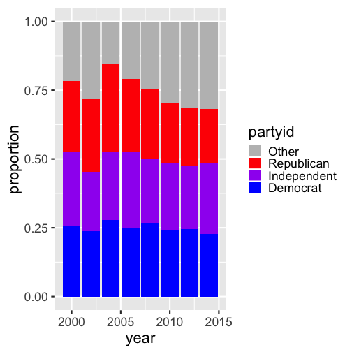

```r
> plot_data %>%
+ ggplot(aes(x=year, y=proportion, fill=partyid)) +
+   geom_bar(position = "fill", stat = "identity") +
+   scale_fill_manual(values = party_colors)
```

## Dates and times

### Date and time objects in R

- Dates and times are not well captured as strings (since you can't do math with them) or as numbers (since date-time arithmetic is irregular), so they need their own data type
- we'll use the `tidyverse`-adjacent `lubridate` package to provide work with that data type

```r
> library(lubridate) # install.package("lubridate")

Attaching package: 'lubridate'
The following object is masked from 'package:base':

    date
```

- The data types that we will work with are `date` and `dttm` (date-time, also unhelpfully called POSIXct elsewhere in R).

```r
> tibble(date_time = now(), # a date-time (dttm), prints as a string
+        date = today()) # a date, also prints as a string
# A tibble: 1 x 2
  date_time           date
  <dttm>              <date>
1 2019-02-16 15:13:27 2019-02-16
```

- Always use the simplest possible data type that works for your needs. Date-times are more complicated because of the need to handle time zones.

### Creating dates from a string (or number)

- Dates:

```r
> c(ymd("2017-01-31"), mdy("January 31st, 2017"),
+   dmy("31-Jan-2017"), ymd(20170131))
[1] "2017-01-31" "2017-01-31" "2017-01-31" "2017-01-31"
```

- Date-times

```r
> ymd_hms("2017-01-31 20:11:59")
[1] "2017-01-31 20:11:59 UTC"
> mdy_hm("01/31/2017 08:01")
[1] "2017-01-31 08:01:00 UTC"
```

- All of these get printed out as strings, but they are actually `date` or dttm objects
- these also all work on vectors, even if they fromatted heterogenously

```r
> x <- c(20090101, "2009-01-02", "2009 01 03", "2009-1-4",
+        "2009-1, 5", "Created on 2009 1 6", "200901 !!! 07")
> ymd(x)
[1] "2009-01-01" "2009-01-02" "2009-01-03" "2009-01-04" "2009-01-05"
[6] "2009-01-06" "2009-01-07"
```

- these functions are all pretty smart and detect most common delimitors (-, /, :, etc.), but you should check their input and output with sample data to make sure they are working correctly

### Creating dates from components

- Sometimes the dates and times you get are split up (usually in columns)

```r
> flights %>%
+   select(year, month, day, hour, minute)
# A tibble: 336,776 x 5
    year month   day  hour minute
   <int> <int> <int> <dbl>  <dbl>
 1  2013     1     1     5     15
 2  2013     1     1     5     29
 3  2013     1     1     5     40
 4  2013     1     1     5     45
 5  2013     1     1     6      0
 6  2013     1     1     5     58
 7  2013     1     1     6      0
 8  2013     1     1     6      0
 9  2013     1     1     6      0
10  2013     1     1     6      0
# … with 336,766 more rows
```

### Creating dates from components

- You can join them into dates or datetimes with `make_date()` or `make_datetime()`

```r
> flights %>%
+   select(year, month, day, hour, minute) %>%
+   mutate(departure = make_datetime(year, month, day, hour, minute))
# A tibble: 336,776 x 6
    year month   day  hour minute departure
   <int> <int> <int> <dbl>  <dbl> <dttm>
 1  2013     1     1     5     15 2013-01-01 05:15:00
 2  2013     1     1     5     29 2013-01-01 05:29:00
 3  2013     1     1     5     40 2013-01-01 05:40:00
 4  2013     1     1     5     45 2013-01-01 05:45:00
 5  2013     1     1     6      0 2013-01-01 06:00:00
 6  2013     1     1     5     58 2013-01-01 05:58:00
 7  2013     1     1     6      0 2013-01-01 06:00:00
 8  2013     1     1     6      0 2013-01-01 06:00:00
 9  2013     1     1     6      0 2013-01-01 06:00:00
10  2013     1     1     6      0 2013-01-01 06:00:00
# … with 336,766 more rows
```

### Creating dates from components

- lets do this for all of the times in the `flights` data frame

```r
> flights %>%
+   head() %>%
+   pull(arr_time)
[1]  830  850  923 1004  812  740
```

- note that `arr_time`, `sched_arr_time`, `dep_time`, and `sched_dep_time` are numeric and in an HHMM format! We have to fix that first (why is this bad?)

```r
> flights_fixed = flights %>%
+   mutate(arr_time_hour = str_sub(arr_time, 1, -3) %>% as.numeric(),
+          arr_time_min = str_sub(arr_time, -2, -1) %>% as.numeric(),
+          sched_arr_time_hour = str_sub(sched_arr_time, 1, -3) %>% as.numeric(),
+          sched_arr_time_min = str_sub(sched_arr_time, -2, -1) %>% as.numeric(),
+          dep_time_hour = str_sub(dep_time, 1, -3) %>% as.numeric(),
+          dep_time_min = str_sub(dep_time, -2, -1) %>% as.numeric(),
+          sched_dep_time_hour = str_sub(sched_dep_time, 1, -3) %>% as.numeric(),
+          sched_dep_time_min = str_sub(sched_dep_time, -2, -1) %>% as.numeric())
```

- Why does `str_sub()` work even though the thing being passed to it is numeric?
- This is a lot of typing and copy-paste. Later we will see how to write our own functions that make this less work and reduce the potential for typos

### Creating dates from components

- Now we can aggregate all of these columns into nice `dttm`s

```r
> flights_dt = flights_fixed %>%
+   # filter(!is.na(dep_time), !is.na(arr_time)) %>%
+   mutate(
+     dep_time = make_datetime(year, month, day,
+                              dep_time_hour, dep_time_min),
+     arr_time = make_datetime(year, month, day,
+                              arr_time_hour, arr_time_min),
+     sched_dep_time = make_datetime(year, month, day,
+                                    sched_dep_time_hour, sched_dep_time_min),
+     sched_arr_time = make_datetime(year, month, day,
+                                    sched_arr_time_hour, sched_dep_time_min)
+   ) %>%
+   select(ends_with("time"), origin, dest, ends_with("delay"))
> head(flights_dt)
# A tibble: 6 x 9
  dep_time            sched_dep_time      arr_time
  <dttm>              <dttm>              <dttm>
1 2013-01-01 05:17:00 2013-01-01 05:15:00 2013-01-01 08:30:00
2 2013-01-01 05:33:00 2013-01-01 05:29:00 2013-01-01 08:50:00
3 2013-01-01 05:42:00 2013-01-01 05:40:00 2013-01-01 09:23:00
4 2013-01-01 05:44:00 2013-01-01 05:45:00 2013-01-01 10:04:00
5 2013-01-01 05:54:00 2013-01-01 06:00:00 2013-01-01 08:12:00
6 2013-01-01 05:54:00 2013-01-01 05:58:00 2013-01-01 07:40:00
# … with 6 more variables: sched_arr_time <dttm>, air_time <dbl>,
#   origin <chr>, dest <chr>, dep_delay <dbl>, arr_delay <dbl>
```

### Plotting with dates

- ggplot2 understands `ddtm`s

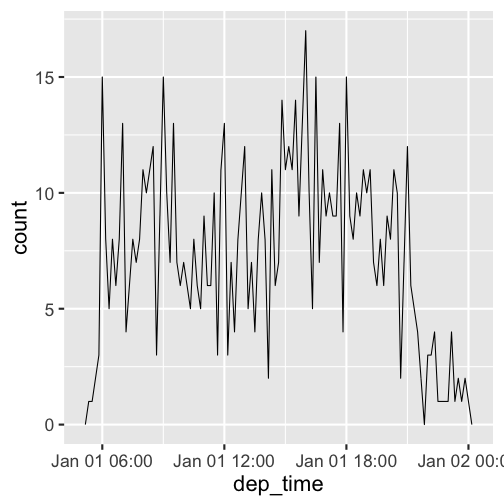

```r
> flights_dt %>%
+   filter(ymd(20130101) < dep_time & dep_time < ymd(20130102)) %>% # get data from jan 1 2013
+ ggplot(aes(dep_time)) + # plot how many flights were leaving at each time of day
+   geom_freqpoly(binwidth = 600) # 600 s = 10 minutes
```

### Accessing dttm elements

- You can pull out individual parts of the date with the accessor functions `year()`, `month()`, `mday()` (day of the month), `yday()` (day of the year), `wday()` (day of the week), `hour()`, `minute()`, and `second()`

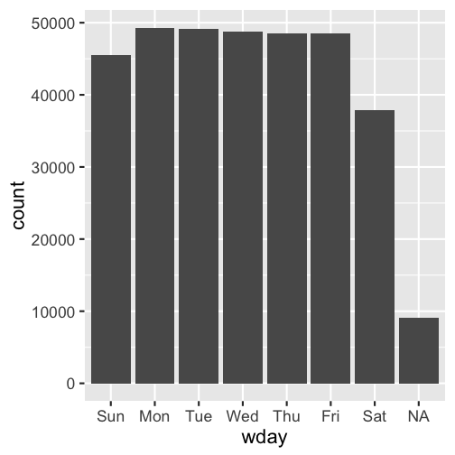

```r
> flights_dt %>%
+   mutate(wday = wday(dep_time, label = TRUE)) %>%
+   ggplot(aes(x = wday)) +
+     geom_bar()
```

### Accessing dttm elements

- You can pull out individual parts of the date with the accessor functions `year()`, `month()`, `mday()` (day of the month), `yday()` (day of the year), `wday()` (day of the week), `hour()`, `minute()`, and `second()`

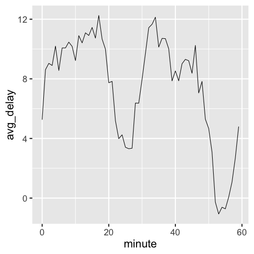

```r
> flights_dt %>%
+   filter(!is.na(dep_time)) %>%
+   mutate(minute = minute(dep_time)) %>%
+   group_by(minute) %>%
+   summarise(
+     avg_delay = mean(arr_delay, na.rm = TRUE),
+     n = n()) %>%
+ ggplot(aes(minute, avg_delay)) +
+   geom_line()
```

### Date-time arithmetic

We will disucss `dttm` subtraction, addition, and division. These require the following data types:

- durations, which represent an exact number of seconds.
- periods, which represent human units like weeks and months.
- intervals, which represent a starting and ending point.

### Durations

- Durations represent an exact span of time (i.e. in seconds)

```r
> usa_age <- today() - ymd(17760704)
> usa_age
Time difference of 88615 days
```

- Subtracting `dttm`s in R gives something called a `difftime`, which ambiguously represents differences in weeks, days, hours, or seconds. A `duration` always uses seconds so it is preferable.
- You can conver to a duration with `as.duration()`

```r
> as.duration(usa_age)
[1] "7656336000s (~242.61 years)"
```

- `dseconds()`, `dminutes()`, `dhours()`, `ddays()`, `dweeks()`, and `dyears()` make durations of the given length of time and are vectorized

```r
> ddays(194)
[1] "16761600s (~27.71 weeks)"
> dweeks(1:4)
[1] "604800s (~1 weeks)"  "1209600s (~2 weeks)" "1814400s (~3 weeks)"
[4] "2419200s (~4 weeks)"
```

### Duration arithmetic

- Durations can be added together and multiplied by numbers

```r
> 2 * (as.duration(usa_age) + dyears(1) + dweeks(12) + dhours(15))
[1] "15390367200s (~487.69 years)"
```

- Or added and subtracted from `ddtm`s

```r
> today() - as.duration(usa_age) # should give July 4 1776
[1] "1776-07-04"
```

- Weird things can happen with time zones

```r
> one_pm <- ymd_hms("2016-03-12 13:00:00", tz = "America/New_York")
> one_pm
[1] "2016-03-12 13:00:00 EST"
> one_pm + ddays(1) # not 1 PM anymore?!
[1] "2016-03-13 14:00:00 EDT"
```

### Periods

- `Period`s are like `Duration`s but in “natural” human units
- `seconds()`, `minutes()`, `hours()`, `days()`, `weeks()`, `months()`, and `years()` make durations of the given length of time

```r
> days(194)
[1] "194d 0H 0M 0S"
> weeks(5:9)
[1] "35d 0H 0M 0S" "42d 0H 0M 0S" "49d 0H 0M 0S" "56d 0H 0M 0S"
[5] "63d 0H 0M 0S"
```

- Question: Why is there `months()` but no `dmonths()`?

### Period arithmetic

```r
> 2 * (dyears(1) + dweeks(12) + dhours(15))
[1] "77695200s (~2.46 years)"
```

- Or added and subtracted from `ddtm`s

```r
> today() - as.period(usa_age) # should give July 4 1776
[1] "1776-07-04"
```

- And they do more of what you would expect given daylight savings

```r
> one_pm <- ymd_hms("2016-03-12 13:00:00", tz = "America/New_York")
> one_pm
[1] "2016-03-12 13:00:00 EST"
> one_pm + days(1) # it knows that one "day" on this day is actually 23 hours, not 24
[1] "2016-03-13 13:00:00 EDT"
```